# DATA 624 Project 1

Warner Alexis

2025-03-30

## **Project 1**

This project consists of 3 parts - two required and one bonus and is worth 15% of your grade. The project is due at 11:59 PM on Sunday Oct 25. I will accept late submissions with a penalty until the meetup after that when we review some projects.

**ATM Forecast** The bar graph illustrates the total cash withdrawals (in hundreds of dollars) for each ATM machine across the dataset. ATM4 stands out with the highest total cash withdrawn at **173,026**, followed by ATM1 and ATM2 with **30,367** and **22,716** respectively. ATM3, on the other hand, shows a significantly lower total of just **263**, suggesting it was either inactive or only recently deployed during the data collection period. The underlying dataset contains **3 columns** (`DATE`, `ATM`, `Cash`) and **1,474 rows**, representing individual withdrawal records across different dates and machines. This analysis helps identify usage intensity and transaction volume per ATM, which is essential for forecasting and operational planning.

```r
# Loading Libraries
library(readxl)
library(dplyr)
```

```r
library(ggplot2)
library(lubridate)
library(forecast)
library(tidyr)
library(tsibble)
library(feasts)
library(fable)
library(urca)
library(writexl)

df <- read_excel("ATM624Data.xlsx", sheet = "ATM Data")

# change df timestamps because of the way excell interpret it
df <- df %>% mutate(DATE = as.Date(DATE, origin = "1899-12-30"))
head(df)
```

```
## # A tibble: 6 × 3
##   DATE       ATM    Cash
##   <date>     <chr> <dbl>
## 1 2009-05-01 ATM1     96
## 2 2009-05-01 ATM2    107
## 3 2009-05-02 ATM1     82
## 4 2009-05-02 ATM2     89
## 5 2009-05-03 ATM1     85
## 6 2009-05-03 ATM2     90
```

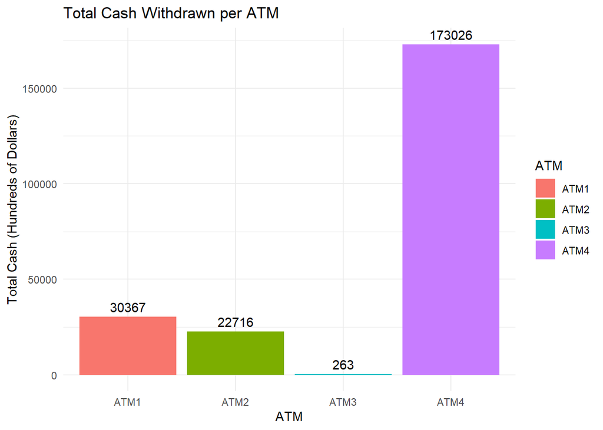

```r
# Summarize total cash per ATM with NA handled
atm_totals <- df |>
  group_by(ATM) |>
  summarise(total_cash = sum(Cash, na.rm = TRUE)) |>
  filter(!is.na(ATM))  # Remove any NA ATM labels

# Create bar plot
ggplot(atm_totals, aes(x = ATM, y = total_cash, fill = ATM)) +
  geom_bar(stat = "identity") +
  geom_text(aes(label = round(total_cash, 0)), vjust = -0.5) +
  labs(title = "Total Cash Withdrawn per ATM",
       x = "ATM",
       y = "Total Cash (Hundreds of Dollars)") +
  theme_minimal()
```

we first created a complete daily date sequence and merged it with our ATM withdrawal data to ensure no days are missing. Any missing values (i.e., days with no withdrawals) were filled with mean values for each ATM. Then, we reshaped the data from wide to long format and converted it into a tsibble, which is required for time series plotting using the autoplot() function. Finally, we generated a faceted time series plot with individual y-axis scales for each ATM, allowing us to clearly visualize daily withdrawal patterns across all machines.

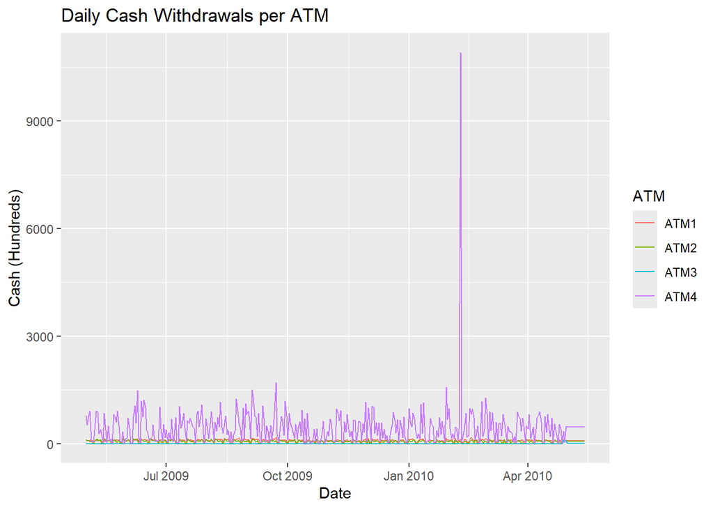

```r
# Ensure complete time series per ATM
data_wide <- df %>%
  group_by(ATM, DATE) %>%
  summarise(Cash = sum(Cash), .groups = 'drop') %>%
  tidyr::pivot_wider(names_from = ATM, values_from = Cash)
# Fill in missing days with 0s (if needed)
full_dates <- seq(min(df$DATE), max(df$DATE), by = "day")
atm_means <- data_wide %>%
  summarise(
    ATM1 = mean(ATM1, na.rm = TRUE),
    ATM2 = mean(ATM2, na.rm = TRUE),
    ATM3 = mean(ATM3, na.rm = TRUE),
    ATM4 = mean(ATM4, na.rm = TRUE)
  )

# Fill missing values with those means
data_full <- data.frame(DATE = full_dates) %>%
  left_join(data_wide, by = "DATE") %>%
  tidyr::replace_na(list(
    ATM1 = atm_means$ATM1,
    ATM2 = atm_means$ATM2,
    ATM3 = atm_means$ATM3,
    ATM4 = atm_means$ATM4
  ))

# Convert to long format and tsibble
data_long <- data_full %>%
  pivot_longer(cols = starts_with("ATM"), names_to = "ATM", values_to = "Cash") %>%
  as_tsibble(index = DATE, key = ATM)

# Plot using autoplot
autoplot(data_long, Cash) +
  labs(title = "Daily Cash Withdrawals per ATM", y = "Cash (Hundreds)", x = "Date")
```

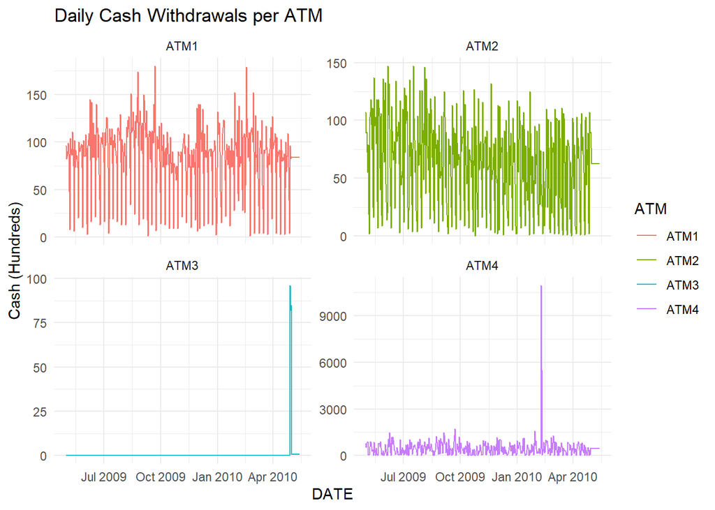

```r
# Plot with autoplot and free scales
autoplot(data_long, Cash) +
  facet_wrap(~ATM, scales = "free_y") +
  labs(title = "Daily Cash Withdrawals per ATM",
       x = "DATE",
       y = "Cash (Hundreds)") +
  theme_minimal()
```

## ATM Forecast

### ATM1

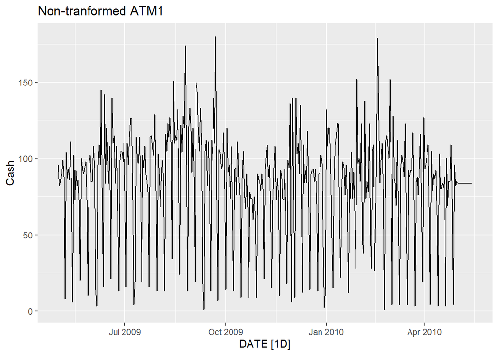

```r
# Create tsibble
ts_data <- data_long %>%
  as_tsibble(index = DATE, key = ATM)

# for atm1

ts_data %>%
  filter(ATM == "ATM1") %>%
  autoplot(Cash) +
  ggtitle("Non-tranformed ATM1")
```

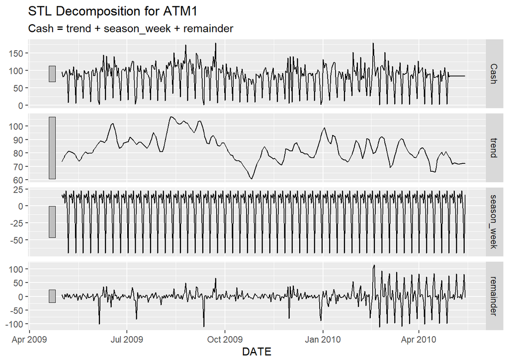

```r
ts_data %>%
  filter(ATM == "ATM1") %>%
  model(STL(Cash ~ season(window = "periodic"), robust = TRUE)) %>%
  components() %>%
  autoplot() +
  labs(title = "STL Decomposition for ATM1")
```

```r
ts_data <- ts_data %>% select(-`NA`)
# STL decomposition
stl_model <- ts_data %>%
  filter(ATM == "ATM1") %>%
  model(STL(Cash ~ season(window = "periodic")))

# Extract components
components <- components(stl_model)

# Check if remainder is stationary (Augmented Dickey-Fuller test)

adf_test <- ur.df(components$remainder, type = "drift", selectlags = "AIC")
summary(adf_test)
```

```
##
## ###############################################
## # Augmented Dickey-Fuller Test Unit Root Test #
## ###############################################
##
## Test regression drift
##
##
## Call:
## lm(formula = z.diff ~ z.lag.1 + 1 + z.diff.lag)
##
## Residuals:
##     Min      1Q  Median      3Q     Max
## -87.595  -9.177   0.089  12.061  76.842
##
## Coefficients:
##             Estimate Std. Error t value Pr(>|t|)
## (Intercept) -0.01938    1.17240  -0.017    0.987
## z.lag.1     -1.58670    0.06801 -23.331   <2e-16 ***
## z.diff.lag   0.45778    0.04623   9.902   <2e-16 ***
## ---
## Signif. codes:  0 '***' 0.001 '**' 0.01 '*' 0.05 '.' 0.1 ' ' 1
##
## Residual standard error: 22.76 on 374 degrees of freedom
## Multiple R-squared:  0.6389, Adjusted R-squared:  0.637
## F-statistic: 330.9 on 2 and 374 DF,  p-value: < 2.2e-16
##
##
## Value of test-statistic is: -23.331 272.1682
##
## Critical values for test statistics:
##       1pct  5pct 10pct
## tau2 -3.44 -2.87 -2.57
## phi1  6.47  4.61  3.79
```

```r
# Step 1: Filter data for ATM1
atm1_tsibble <- ts_data %>%
  filter(ATM == "ATM1")

# Step 2: Fit ARIMA model (automatically selected orders)
arima_model <- atm1_tsibble %>%
  model(ARIMA(Cash))

# Step 3: Model report
report(arima_model)
```

```
## Series: Cash
## Model: ARIMA(0,0,1)(0,1,2)[7]
##
## Coefficients:
##          ma1     sma1     sma2
##       0.1543  -0.5794  -0.1216
## s.e.  0.0548   0.0500   0.0510
##
## sigma^2 estimated as 566.4:  log likelihood=-1707.56
## AIC=3423.12   AICc=3423.23   BIC=3438.8
```

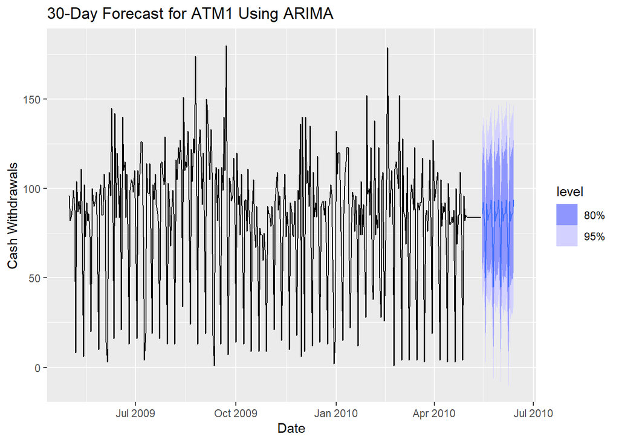

```r
# Step 4: Forecast 30 days ahead
forecast_arima <- arima_model %>%
  forecast(h = "30 days")

# Step 5: Plot forecast with historical data
autoplot(forecast_arima, atm1_tsibble) +
  labs(title = "30-Day Forecast for ATM1 Using ARIMA",
       y = "Cash Withdrawals", x = "Date")
```

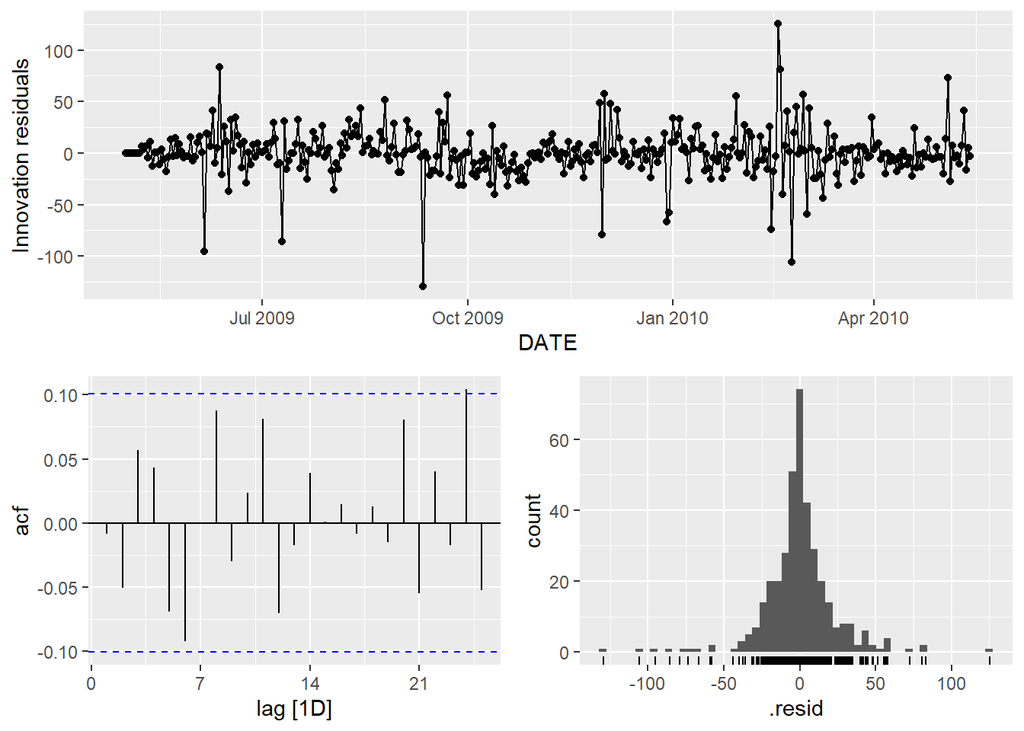

```r
# Step 6: Residual diagnostics
# a) ACF plot of residuals
arima_model %>%
  gg_tsresiduals()
```

```r
# b) Ljung-Box test for white noise residuals
arima_model %>%
  augment() %>%
  features(.innov, ljung_box, lag = 24, dof = 3)
```

```
## # A tibble: 1 × 4
##   ATM   .model      lb_stat lb_pvalue
##   <chr> <chr>         <dbl>     <dbl>
## 1 ATM1  ARIMA(Cash)    26.2     0.200
```

```r
# extract point from forecast only
forecast_atm1 <- forecast_arima %>%
  as_tibble() %>%
  select(DATE, ATM, .mean) %>%
  pivot_wider(names_from = ATM, values_from = .mean)

# Save to Excel
write_xlsx(forecast_atm1, "ATM1_Forecast_May2010.xlsx")
```

### ATM2

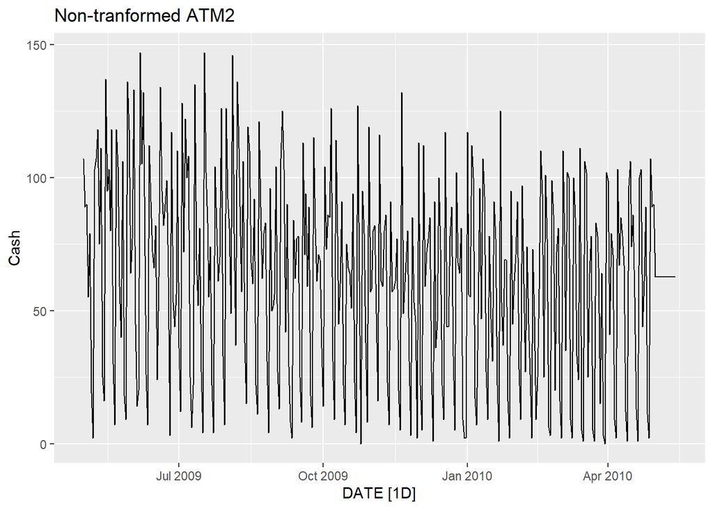

```r
ts_data %>%
  filter(ATM == "ATM2") %>%
  autoplot(Cash) +
  ggtitle("Non-tranformed ATM2")
```

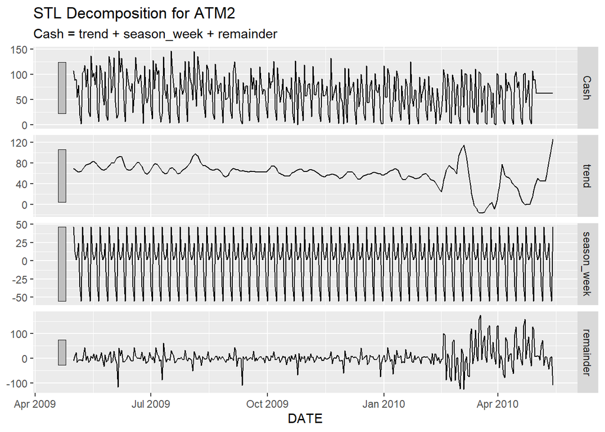

```r
ts_data %>%
  filter(ATM == "ATM2") %>%
  model(STL(Cash ~ season(window = "periodic"), robust = TRUE)) %>%
  components() %>%
  autoplot() +
  labs(title = "STL Decomposition for ATM2")
```

```r
# --- 1. Extract ATM2 from data_long ---
atm2_data <- ts_data %>%
  filter(ATM == "ATM2")

# --- 2. Check if it's stationary (ADF test) ---
atm2_data %>% features(Cash, unitroot_kpss)
```

```
## # A tibble: 1 × 3
##   ATM   kpss_stat kpss_pvalue
##   <chr>     <dbl>       <dbl>
## 1 ATM2       2.07        0.01
```

```r
# --- 3. Differencing to remove trend and seasonality ---
# First difference: removes trend
# Seasonal difference: removes weekly seasonality (lag = 7)
atm2_stationary <- atm2_data %>%
  mutate(diff_cash = difference(Cash, differences = 1),
         diff_seasonal = difference(Cash, lag = 7))
```

The null hypothesis of the KPSS test is that the series is stationary Since the p-value is 0.01 , we reject the null hypothesis. the unitroop_kpps test confirms that the ATM2 series is non-stationary and requires differencing before modeling.

These plots help you visually inspect if: - Residuals are approximately normally distributed - There’s no autocorrelation left (ACF spikes should be within the blue bands) - The model is well-behaved (i.e., white noise residuals)

The Ljung-Box test was conducted on the residuals of the ARIMA model fitted to ATM2 in order to assess whether any autocorrelation remained after model fitting. The test returned a statistic of 8.47 with a p-value of 0.583 at lag 10. Since the p-value is greater than the conventional threshold of 0.05, we fail to reject the null hypothesis that the residuals are independently distributed. This indicates that the residuals behave like white noise and do not exhibit significant autocorrelation, suggesting that the ARIMA model for ATM2 provides an adequate fit to the data.

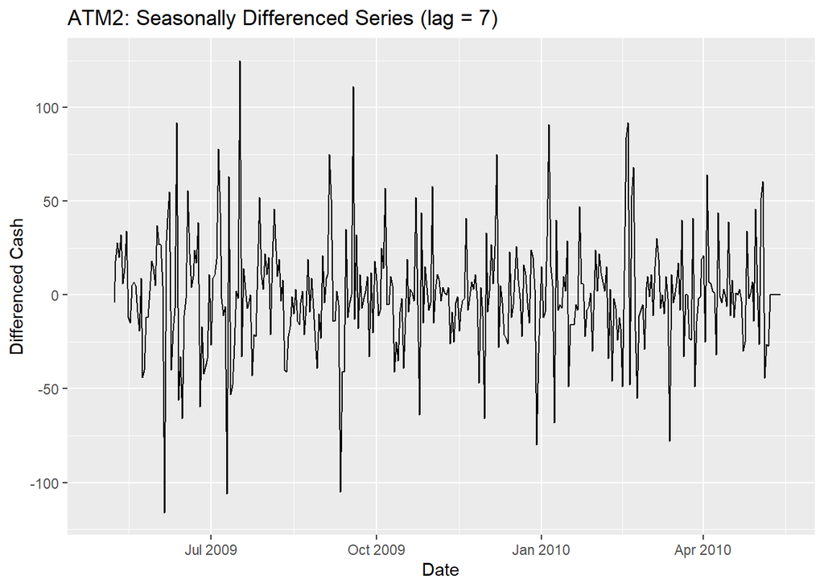

```r
# Plot transformed (stationary) series
atm2_stationary %>%
  autoplot(diff_seasonal, na.rm = TRUE) +
  labs(title = "ATM2: Seasonally Differenced Series (lag = 7)",
       y = "Differenced Cash", x = "Date")
```

```r
# Apply first-order differencing
atm2_diff <- atm2_data %>%
  mutate(diff_cash = difference(Cash, differences = 1)) %>%
  filter(!is.na(diff_cash))

# Test again after differencing
atm2_diff %>% features(diff_cash, unitroot_kpss)
```

```
## # A tibble: 1 × 3
##   ATM   kpss_stat kpss_pvalue
##   <chr>     <dbl>       <dbl>
## 1 ATM2     0.0104         0.1
```

```r
atm2_model <- atm2_data %>%
  model(ARIMA = ARIMA(Cash))

report(atm2_model)
```

```
## Series: Cash
## Model: ARIMA(2,0,2)(0,1,1)[7]
##
## Coefficients:
##           ar1      ar2     ma1     ma2     sma1
##       -0.4380  -0.9154  0.4921  0.8017  -0.7701
## s.e.   0.0525   0.0383  0.0814  0.0560   0.0392
##
## sigma^2 estimated as 602.2:  log likelihood=-1718.39
## AIC=3448.78   AICc=3449.01   BIC=3472.29
```

```r
atm2_model <- atm2_data %>%
  model(ARIMA = ARIMA(Cash))

report(atm2_model)
```

```
## Series: Cash
## Model: ARIMA(2,0,2)(0,1,1)[7]
##
## Coefficients:
##           ar1      ar2     ma1     ma2     sma1
##       -0.4380  -0.9154  0.4921  0.8017  -0.7701
## s.e.   0.0525   0.0383  0.0814  0.0560   0.0392
##
## sigma^2 estimated as 602.2:  log likelihood=-1718.39
## AIC=3448.78   AICc=3449.01   BIC=3472.29
```

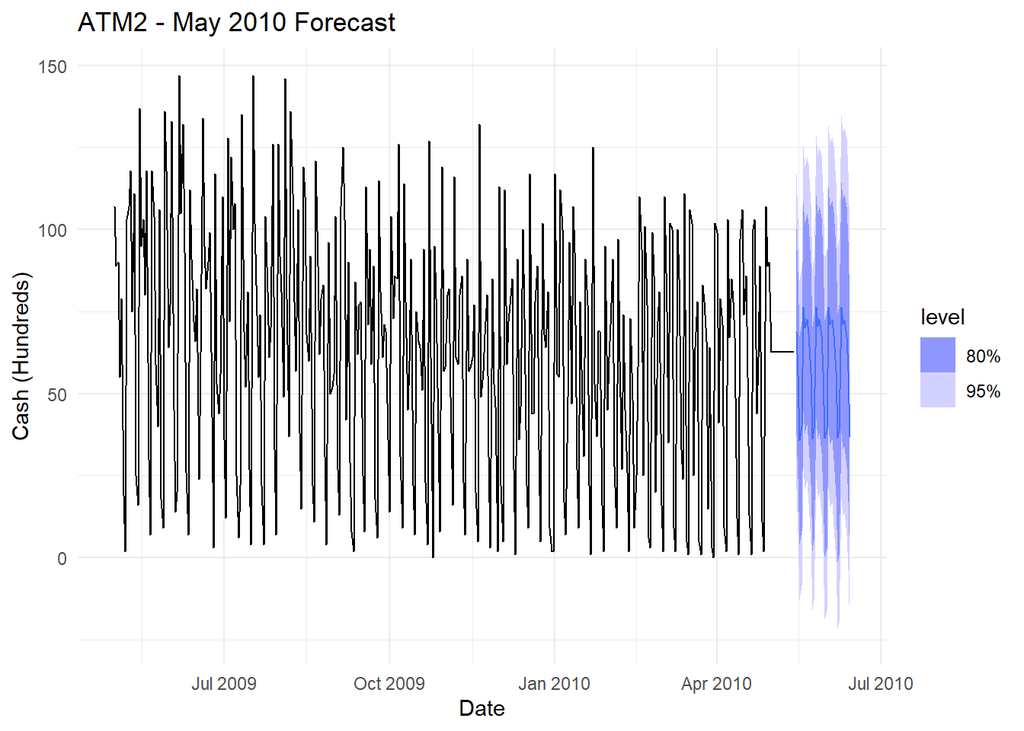

```r
atm2_forecast <- atm2_model %>%
  forecast(h = "31 days")

autoplot(atm2_forecast, atm2_data) +
  labs(title = "ATM2 - May 2010 Forecast",
       y = "Cash (Hundreds)", x = "Date") +
  theme_minimal()
```

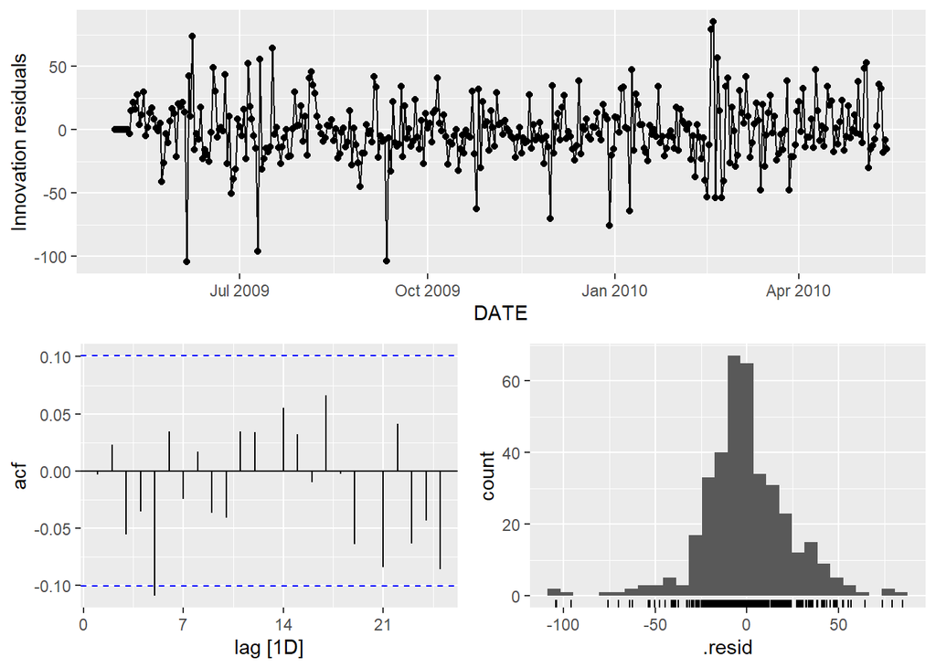

```r
atm2_model %>%
  gg_tsresiduals()
```

```r
atm2_model %>%
  augment() %>%
  features(.resid, ljung_box, lag = 10)
```

```
## # A tibble: 1 × 4
##   ATM   .model lb_stat lb_pvalue
##   <chr> <chr>    <dbl>     <dbl>
## 1 ATM2  ARIMA     8.47     0.583
```

```r
# print the files
forecast_atm2 <- atm2_forecast %>%
  as_tibble() %>%
  select(DATE, ATM, .mean) %>%
  pivot_wider(names_from = ATM, values_from = .mean)

# Save to Excel
write_xlsx(forecast_atm2, "ATM2_Forecast_May2010.xlsx")
```

### ATM3

[figure not shown]

```r
ts_data %>%
  filter(ATM == "ATM3") %>%
  autoplot(Cash) +
  ggtitle("Non-tranformed ATM2")
```

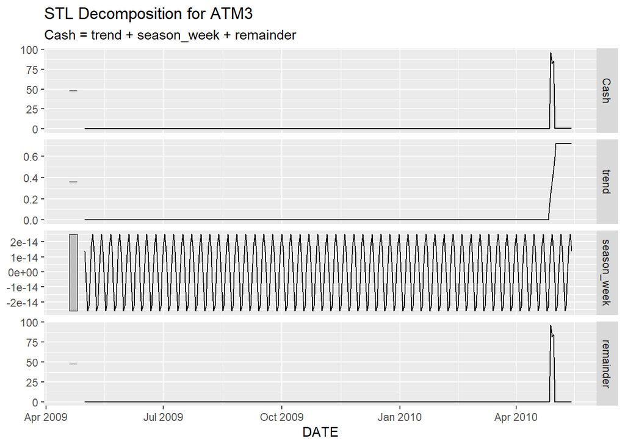

```r
ts_data %>%
  filter(ATM == "ATM3") %>%
  model(STL(Cash ~ season(window = "periodic"), robust = TRUE)) %>%
  components() %>%
  autoplot() +
  labs(title = "STL Decomposition for ATM3")
```

```r
# --- 1. Extract ATM2 from data_long ---
atm3_data <- ts_data %>%
  filter(ATM == "ATM3")

# --- 2. Check if it's stationary (ADF test) ---
atm3_data %>% features(Cash, unitroot_kpss)
```

```
## # A tibble: 1 × 3
##   ATM   kpss_stat kpss_pvalue
##   <chr>     <dbl>       <dbl>
## 1 ATM3      0.375      0.0880
```

Based on the grapgh, ATM3 appear to be new and lack historical pattern. The KPSS test was conducted on the ATM3 cash withdrawal time series to evaluate its stationarity. The test yielded a KPSS statistic of 0.375 with a corresponding p-value of 0.088. Since the p-value is greater than the conventional significance level of 0.05, we fail to reject the null hypothesis that the series is stationary. This indicates there is no strong evidence of a unit root, and the data can be considered stationary. Therefore, based on the KPSS test results, the ATM3 time series does not exhibit significant non-stationarity and may be suitable for modeling without further differencing.

This ARIMA(0,0,2) model assumes the data is already stationary and captures the short-term autocorrelation using two moving average components. The model fits the data well, as indicated by the significant MA coefficients and relatively low AIC. It’s a suitable model for forecasting if the residual diagnostics confirm white noise behavior.

In Order to make this model better, we need more historical data. This prediction is only based on 3 days. Although an ARIMA(0,0,2) model was successfully fitted to the ATM3 cash withdrawal series, several factors indicate that the model should not be relied upon for meaningful forecasting. The historical data for ATM3 is extremely limited, with most values either zero or constant imputed values, and only a few days reflecting real activity. While the KPSS test suggests the series is stationary (p = 0.088), the residual diagnostics show a lack of meaningful variation, with nearly all residuals close to zero and a single large spike occurring near the end. This pattern suggests the model is likely overfitting a small number of recent values rather than capturing a true underlying pattern. The fitted MA coefficients may appear statistically significant, but in the context of such sparse and uninformative data, they are unlikely to generalize well. Therefore, despite the model’s statistical output, it is recommended to treat ATM3 as a newly active ATM and to defer reliable time series forecasting until more real data becomes available over time.

```r
atm3_real <- ts_data %>%
  filter(ATM == "ATM3", Cash != 0.7205479)
head(atm3_real)
```

```
## # A tsibble: 6 x 3 [1D]
## # Key:       ATM [1]
##   DATE       ATM    Cash
##   <date>     <chr> <dbl>
## 1 2009-05-01 ATM3      0
## 2 2009-05-02 ATM3      0
## 3 2009-05-03 ATM3      0
## 4 2009-05-04 ATM3      0
## 5 2009-05-05 ATM3      0
## 6 2009-05-06 ATM3      0
```

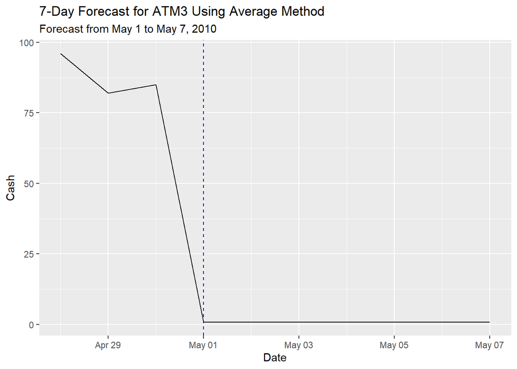

```r
# Calculate average
avg_cash <- mean(atm3_real$Cash)

# Create future dates
future_dates <- seq(from = as.Date("2010-05-01"), by = "day", length.out = 30)

# Create forecast dataframe
atm3_forecast <- tibble(
  DATE = future_dates,
  ATM = "ATM3",
  Cash = avg_cash
)

# Step 4: Combine real and forecasted data
combined <- bind_rows(
  as_tibble(atm3_real),
  atm3_forecast
)

# Filter to a 10-day window (3 actual + 7 forecast)
plot_data <- combined %>%
  filter(DATE >= as.Date("2010-04-28") & DATE <= as.Date("2010-05-07"))

# Plot
ggplot(plot_data, aes(x = DATE, y = Cash)) +
  geom_line(color = "black") +
  geom_vline(xintercept = as.Date("2010-05-01"), linetype = "dashed", color = "blue") +
  labs(
    title = "7-Day Forecast for ATM3 Using Average Method",
    subtitle = "Forecast from May 1 to May 7, 2010",
    y = "Cash", x = "Date"
  )
```

```r
# Step 2: Fit ARIMA model (automatically selected orders)
  atm3_model <- atm3_data %>%
    model(ARIMA(Cash))

  # Step 3: Model report
  report(atm3_model)
```

```
## Series: Cash
## Model: ARIMA(0,0,2)
##
## Coefficients:
##          ma1     ma2
##       0.8492  0.8752
## s.e.  0.0263  0.0268
##
## sigma^2 estimated as 24.45:  log likelihood=-1144.11
## AIC=2294.23   AICc=2294.29   BIC=2306.04
```

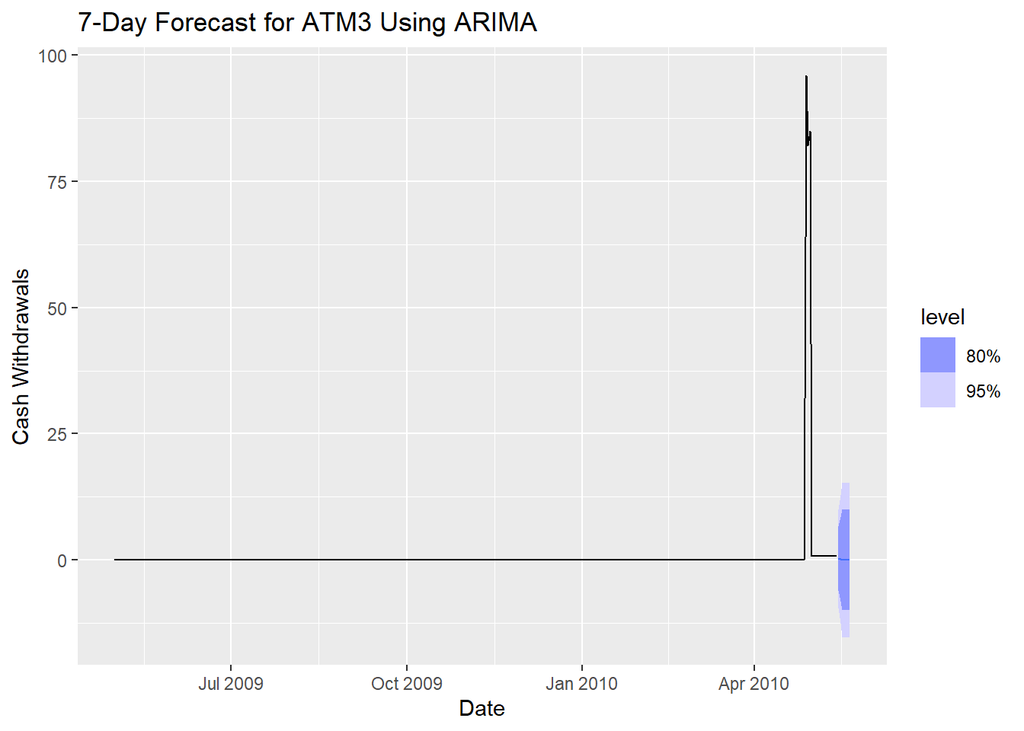

```r
  # Step 4: Forecast 30 days ahead
  forecast_atm3 <- atm3_model %>%
    forecast(h = "7 days")

  # Step 5: Plot forecast with historical data
  autoplot(forecast_atm3, atm3_data) +
    labs(title = "7-Day Forecast for ATM3 Using ARIMA",
         y = "Cash Withdrawals", x = "Date")
```

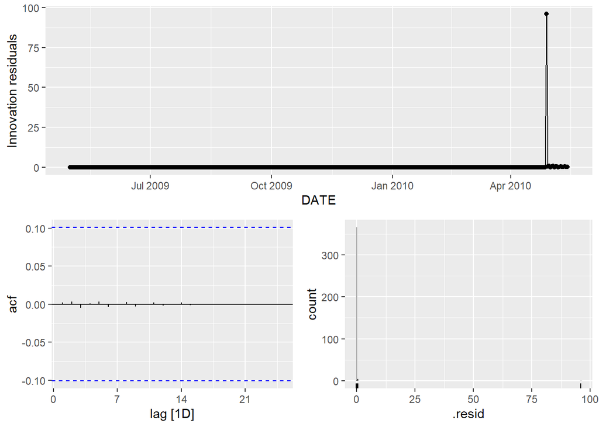

```r
  # Step 6: Residual diagnostics
  # a) ACF plot of residuals
  atm3_model %>%
    gg_tsresiduals()
```

```r
  # b) Ljung-Box test for white noise residuals
  atm3_model %>%
    augment() %>%
    features(.innov, ljung_box, lag = 24, dof = 3)
```

```
## # A tibble: 1 × 4
##   ATM   .model      lb_stat lb_pvalue
##   <chr> <chr>         <dbl>     <dbl>
## 1 ATM3  ARIMA(Cash)  0.0371         1
```

```r
  # extract point from forecast only
  forecast_atm3f <- forecast_atm3 %>%
    as_tibble() %>%
    select(DATE, ATM, .mean) %>%
    pivot_wider(names_from = ATM, values_from = .mean)

  # Save to Excel
  write_xlsx(forecast_atm3f, "ATM3_Forecast_May2010.xlsx")
```

### ATM4

The time series plot of ATM4 displays daily cash withdrawals over the observed period, with most values remaining relatively consistent and moderate in scale. However, there is a clear and dramatic spike in withdrawals around early 2010, where values surge to nearly 10,000 (in hundreds of dollars), indicating a significant outlier or unusual event. Outside of this spike, the series exhibits mild variability with values largely below 1,000, suggesting stable usage with occasional fluctuations. This sharp peak skews the data and would likely impact forecasting models, highlighting the need to address or adjust outliers prior to model fitting.

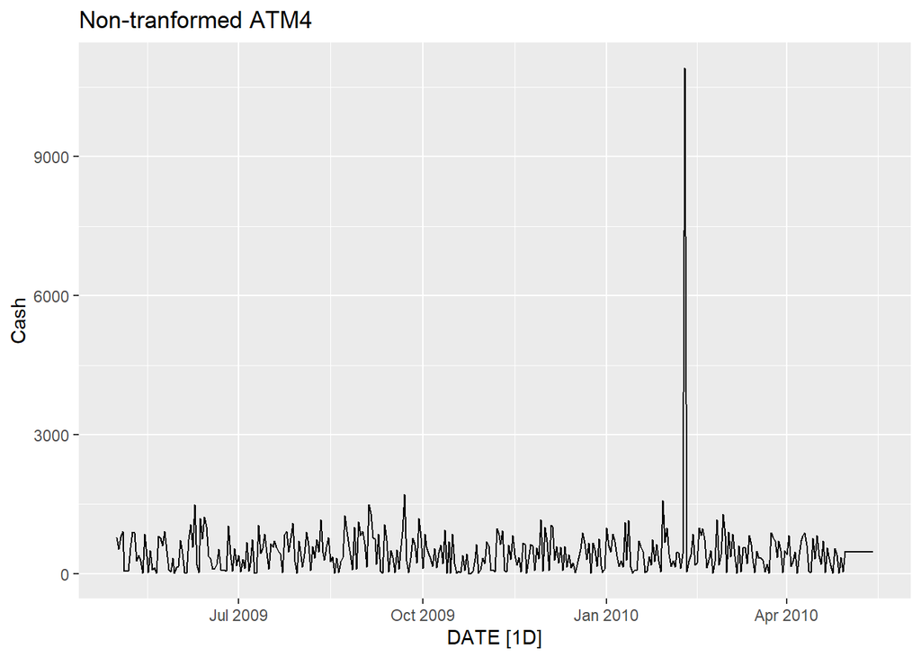

```r
ts_data %>%
  filter(ATM == "ATM4") %>%
  autoplot(Cash) +
  ggtitle("Non-tranformed ATM4")
```

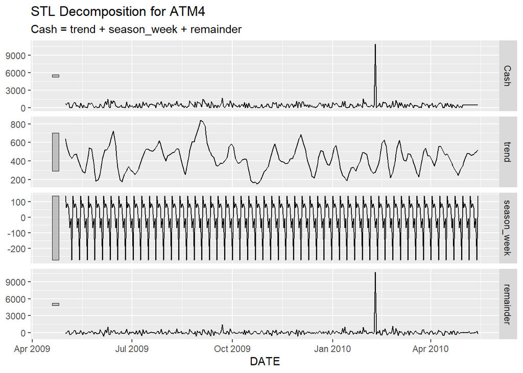

```r
ts_data %>%
  filter(ATM == "ATM4") %>%
  model(STL(Cash ~ season(window = "periodic"), robust = TRUE)) %>%
  components() %>%
  autoplot() +
  labs(title = "STL Decomposition for ATM4")
```

```r
atm4_data <- ts_data %>%
  filter(ATM == "ATM4")
head(atm4_data)
```

```
## # A tsibble: 6 x 3 [1D]
## # Key:       ATM [1]
##   DATE       ATM    Cash
##   <date>     <chr> <dbl>
## 1 2009-05-01 ATM4  777.
## 2 2009-05-02 ATM4  524.
## 3 2009-05-03 ATM4  793.
## 4 2009-05-04 ATM4  908.
## 5 2009-05-05 ATM4   52.8
## 6 2009-05-06 ATM4   52.2
```

```r
# --- 2. Check if it's stationary (ADF test) ---
atm4_data %>% features(Cash, unitroot_kpss)
```

```
## # A tibble: 1 × 3
##   ATM   kpss_stat kpss_pvalue
##   <chr>     <dbl>       <dbl>
## 1 ATM4     0.0767         0.1
```

After replacing the maximum cash value in the ATM4 time series with the mean, the KPSS test was rerun to assess stationarity. The test returned a KPSS statistic of 0.0843 with a p-value of 0.1. Since the p-value exceeds the 0.05 threshold, we fail to reject the null hypothesis that the series is stationary. This indicates that the ATM4 cash withdrawal series remains stationary even after the outlier adjustment. The result confirms that the extreme value did not significantly affect the overall stationarity of the data. With the series now cleaner and statistically stable, it is suitable for further time series modeling and forecasting, such as using an ARIMA approach.

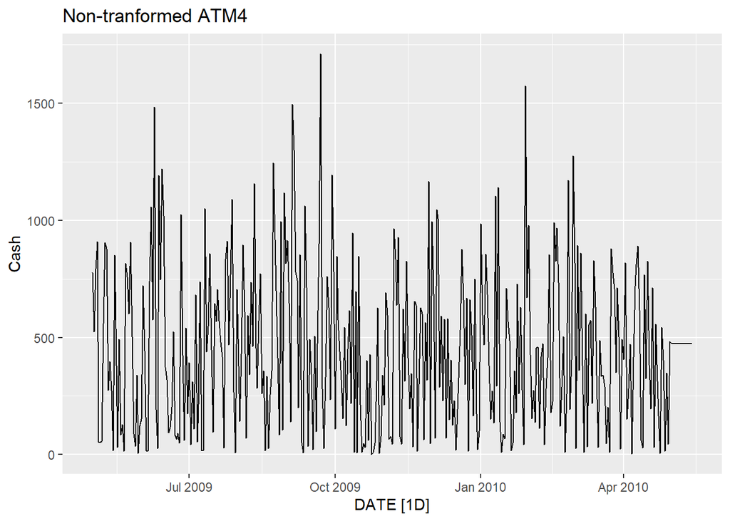

```r
# Step 1: Filter ATM4 data
atm4_clean <- atm4_data %>%
  group_by(ATM) %>%
  mutate(
    # Step 2: Calculate the mean (excluding NA and extreme value)
    mean_cash = mean(Cash[ATM == "ATM4"], na.rm = TRUE),

    # Step 3: Identify max value
    max_cash = max(Cash[ATM == "ATM4"], na.rm = TRUE),

    # Step 4: Replace max with mean
    Cash = ifelse(ATM == "ATM4" & Cash == max_cash, mean_cash, Cash)
  ) %>%
  select(-mean_cash, -max_cash)  # Optional: remove helper columns
# Convert to tsibble

atm4_clean <- atm4_clean %>%
  as_tsibble(index = DATE)






atm4_clean %>%
  autoplot(Cash) +
  ggtitle("Non-tranformed ATM4")
```

```r
# --- 2. Check if it's stationary (ADF test) ---
atm4_clean %>% features(Cash, unitroot_kpss)# --- 2. Check if it's stationary (ADF test) ---
```

```
## # A tibble: 1 × 3
##   ATM   kpss_stat kpss_pvalue
##   <chr>     <dbl>       <dbl>
## 1 ATM4      0.100         0.1
```

```r
atm4_model <- atm4_clean %>%
  model(ARIMA = ARIMA(Cash))

report(atm4_model)
```

```
## Series: Cash
## Model: ARIMA(3,0,2)(1,0,0)[7] w/ mean
##
## Coefficients:
##           ar1      ar2     ar3     ma1     ma2    sar1  constant
##       -0.8855  -0.6709  0.1652  0.9692  0.7935  0.2446  806.7806
## s.e.   0.1045   0.1238  0.0553  0.0957  0.1155  0.0542   47.0171
##
## sigma^2 estimated as 113290:  log likelihood=-2739.82
## AIC=5495.64   AICc=5496.03   BIC=5527.14
```

```
## `mutate_if()` ignored the following grouping variables:
## • Column `ATM`
```

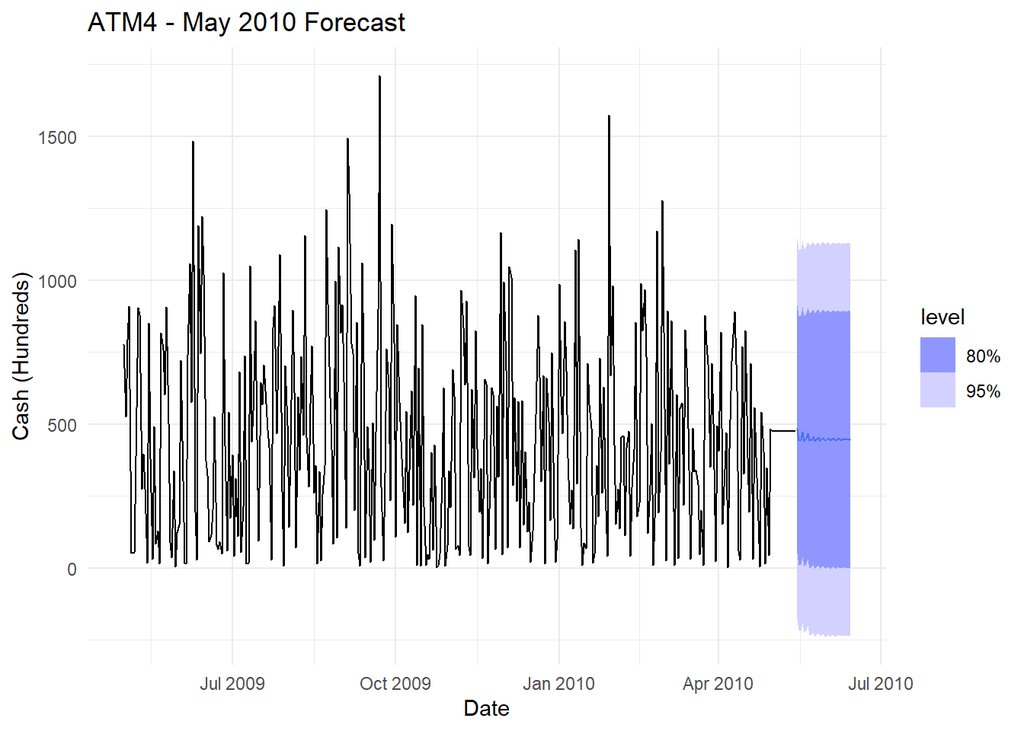

```r
atm4_forecast <- atm4_model %>%
  forecast(h = "31 days")

autoplot(atm4_forecast, atm4_clean) +
  labs(title = "ATM4 - May 2010 Forecast",
       y = "Cash (Hundreds)", x = "Date") +
  theme_minimal()
```

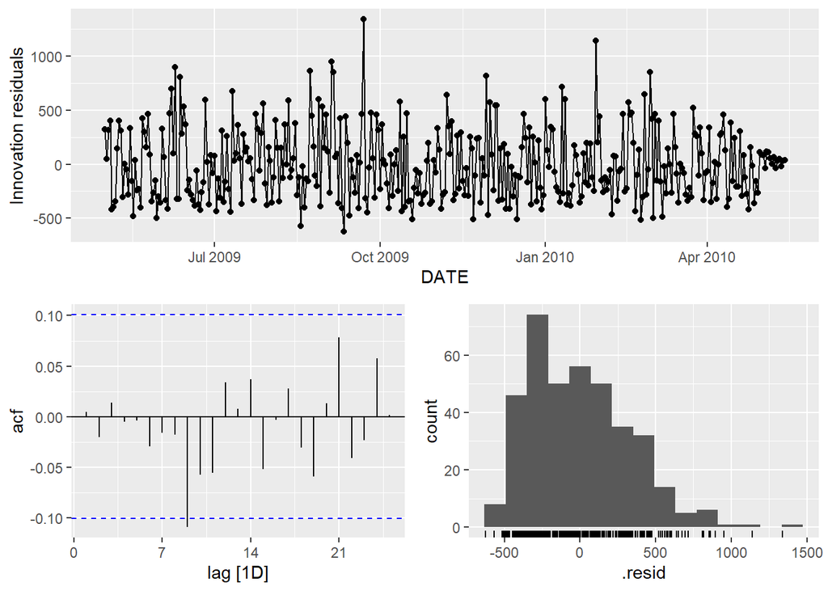

```r
atm4_model %>% gg_tsresiduals()
```

```r
  # b) Ljung-Box test for white noise residuals
  atm4_model %>%
    augment() %>%
    features(.innov, ljung_box, lag = 24, dof = 3)
```

```
## # A tibble: 1 × 4
##   ATM   .model lb_stat lb_pvalue
##   <chr> <chr>    <dbl>     <dbl>
## 1 ATM4  ARIMA     16.9     0.718
```

```r
  # extract point from forecast only
  forecast_atm4 <- atm4_forecast %>%
    as_tibble() %>%
    select(DATE, Cash, .mean) %>%
    pivot_wider(names_from = Cash, values_from = .mean)


  # Save to Excel
  write_xlsx(forecast_atm3f, "ATM4_Forecast_May2010.xlsx")
```